# Kohl-Analysis-MiniProj2

2026-06-18

```r
library(tidyverse)
```

```r
library(plotly)
nbafinals <- read.csv("../data/NBAchampionsdata.csv")
summary(nbafinals)
```

```
##       Year          Team                Game          Win
##  Min.   :1980   Length:220         Min.   :1.0   Min.   :0.0000
##  1st Qu.:1989   Class :character   1st Qu.:2.0   1st Qu.:0.0000
##  Median :1999   Mode  :character   Median :3.0   Median :1.0000
##  Mean   :1999                      Mean   :3.4   Mean   :0.7091
##  3rd Qu.:2009                      3rd Qu.:5.0   3rd Qu.:1.0000
##  Max.   :2018                      Max.   :7.0   Max.   :1.0000
##
##       Home              MP              FG             FGA
##  Min.   :0.0000   Min.   :240.0   Min.   :25.00   Min.   : 62.00
##  1st Qu.:0.0000   1st Qu.:240.0   1st Qu.:33.00   1st Qu.: 75.00
##  Median :1.0000   Median :240.0   Median :37.00   Median : 80.00
##  Mean   :0.5045   Mean   :242.4   Mean   :37.75   Mean   : 80.88
##  3rd Qu.:1.0000   3rd Qu.:240.0   3rd Qu.:42.00   3rd Qu.: 87.00
##  Max.   :1.0000   Max.   :315.0   Max.   :56.00   Max.   :130.00
##
##       FGP               TP              TPA             TPP
##  Min.   :0.2890   Min.   : 0.000   Min.   : 0.00   Min.   :0.0000
##  1st Qu.:0.4298   1st Qu.: 2.000   1st Qu.: 6.75   1st Qu.:0.2500
##  Median :0.4670   Median : 5.000   Median :15.00   Median :0.3585
##  Mean   :0.4665   Mean   : 5.355   Mean   :14.60   Mean   :0.3422
##  3rd Qu.:0.5000   3rd Qu.: 8.000   3rd Qu.:20.00   3rd Qu.:0.4440
##  Max.   :0.6170   Max.   :18.000   Max.   :43.00   Max.   :1.0000
##                                                    NA's   :6
##        FT             FTA             FTP              ORB
##  Min.   : 5.00   Min.   : 8.00   Min.   :0.3680   Min.   : 3.0
##  1st Qu.:15.00   1st Qu.:21.00   1st Qu.:0.6670   1st Qu.: 9.0
##  Median :19.00   Median :26.00   Median :0.7400   Median :12.0
##  Mean   :19.93   Mean   :27.13   Mean   :0.7356   Mean   :12.3
##  3rd Qu.:24.00   3rd Qu.:32.25   3rd Qu.:0.8157   3rd Qu.:15.0
##  Max.   :43.00   Max.   :57.00   Max.   :1.0000   Max.   :27.0
##
##       DRB             TRB            AST            STL
##  Min.   :16.00   Min.   :22.0   Min.   :11.0   Min.   : 1.000
##  1st Qu.:27.00   1st Qu.:38.0   1st Qu.:18.0   1st Qu.: 6.000
##  Median :30.00   Median :42.0   Median :22.0   Median : 8.000
##  Mean   :30.20   Mean   :42.5   Mean   :22.5   Mean   : 7.855
##  3rd Qu.:33.25   3rd Qu.:47.0   3rd Qu.:27.0   3rd Qu.:10.000
##  Max.   :44.00   Max.   :59.0   Max.   :44.0   Max.   :18.000
##
##       BLK              TOV              PF             PTS
##  Min.   : 0.000   Min.   : 4.00   Min.   :12.00   Min.   : 71.00
##  1st Qu.: 3.000   1st Qu.:11.00   1st Qu.:20.00   1st Qu.: 90.75
##  Median : 5.000   Median :14.00   Median :23.00   Median :101.00
##  Mean   : 5.323   Mean   :13.71   Mean   :22.86   Mean   :100.79
##  3rd Qu.: 7.000   3rd Qu.:16.00   3rd Qu.:26.00   3rd Qu.:109.00
##  Max.   :14.000   Max.   :26.00   Max.   :33.00   Max.   :141.00
##
```

```r
#make data more readable
nbafinalsnew <- nbafinals %>%
  mutate(
    Series = paste(Year, Team, sep = " "),
    Result = ifelse(Win == 1, "Win", "Loss"),
    Location = ifelse(Home == 1, "Home", "Away")
    )
```

```r
seriesgames <- ggplot(
    nbafinalsnew, aes(x = Game, y = PTS, group = Series, color = Team,
    text = paste0("<b>", Series, "</b><br>",
    "Game: ", Game, "<br>",
    "Points: ", PTS, "<br>",
    "Result: ", Result, " (", Location, ")<br>"))) +
  geom_line(alpha = 0.8, linewidth = 0.2) +
  geom_point(aes(shape = Result), size = 2) +
  scale_x_continuous(breaks = 1:7) +
  scale_shape_manual(values = c("Win" = 16, "Loss" = 4)) +
  scale_color_viridis_d(option = "turbo") +
  labs(
    title = "NBA Finals Games (1980–2018)",
    x = "Game Number",
    y = "Points Scored",
    color = "Champions",
    shape = "Game Outcome"
  ) +
  theme_minimal()

interactive_plot <- ggplotly(seriesgames)
interactive_plot
```

[interactive chart not shown]

This chart tracks the game-by-game scoring output (PTS) of championship teams across the span of a best-of-seven series.

It visualizes the volatile nature of Finals games, mapping individual game performance trends and illustrating how scoring averages swing between winning and losing efforts as a series progresses.

```r
library(usmap)
library(ggrepel)
```

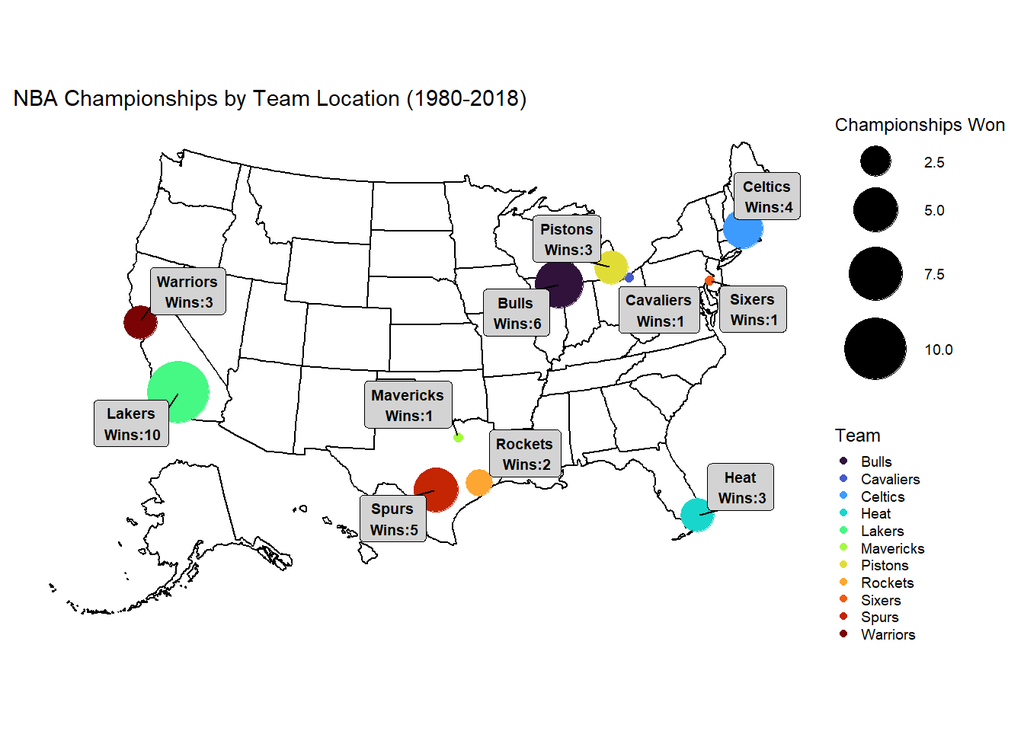

```r
championships_per_team <- nbafinals %>%
  group_by(Year) %>%
  summarise(Team = first(Team)) %>%
  group_by(Team) %>%
  summarise(Championships = n())

team_coordinates <- data.frame(
  Team = c("Lakers", "Bulls", "Spurs", "Celtics", "Pistons", "Heat", "Warriors", "Rockets", "Sixers", "Mavericks", "Cavaliers"),
  City = c("Los Angeles, CA", "Chicago, IL", "San Antonio, TX", "Boston, MA", "Detroit, MI", "Miami, FL", "San Francisco, CA", "Houston, TX", "Philadelphia, PA", "Dallas, TX", "Cleveland, OH"),
  lon  = c(-118.2437, -87.6298, -98.4936, -71.0589, -83.0458, -80.1918, -122.4194, -95.3698, -75.1652, -96.7970, -81.6944),
  lat  = c(34.0522, 41.8781, 29.4241, 42.3601, 42.3314, 25.7617, 37.7749, 29.7604, 39.9526, 32.7767, 41.4993)
)

map_data <- championships_per_team %>%
  left_join(team_coordinates, by = "Team")
map_data_transformed <- usmap_transform(map_data, input_names = c("lon", "lat"))

map_plot <- plot_usmap("states") +
  geom_sf(
    data = map_data_transformed,
    aes(size = Championships, color = Team)) +
  scale_size_continuous(range = c(2,14)) +
  scale_color_viridis_d(option = "turbo") +
  geom_label_repel(
    data=map_data_transformed,
    stat="sf_coordinates",
    aes(label = paste0(Team,"\n Wins:",Championships),geometry=geometry),
    size=2.5,
    fontface="bold",
    fill="lightgrey") +
  labs(
    title = "NBA Championships by Team Location (1980-2018)",
    size = "Championships Won",
    color = "Team"
  ) +
  theme(
    legend.position = "right",
    legend.key.size = unit(0.3,"cm")
  )
map_plot
```

This map plots the physical city coordinates of every NBA franchise that won at least one championship between 1980 and 2018, with bubble sizes representing the total number of titles won.